# Quick Start Guide

## python and conda enviornment setup

The first step is to setup python and other packages required by the CaImAn package. Although python can run perfectly fine by itself, and you can install the packages one by one manually, it is advised to use Conda, a package manager to make everything easier. Conda provides two major benefits: 1. conda manage different set of packages with virtual enviornment, so you can install different version of python and other packages in isolated and self-contained enviornments and they won't interfere with each other. It's like having Windows XP, Windows 7 and Windows 10 all on your machine at the same time, each with its own set of software (MS office, PS etc.) 2. conda makes compling and installing packages easier, since it handles components that are not written in python properly. This is especially valuable when comparing to pip - python's own package manager.

If you are interested in what's going on with all these python, conda and pip stuff and why the complication, **[here](https://jakevdp.github.io/blog/2016/08/25/conda-myths-and-misconceptions/)** is a link that helped me a lot

So here we go, go to the **[homepage of CaImAn](https://github.com/simonsfoundation/CaImAn)** and follow the installation guide, which should guide you through installing python and conda as well as setting up the enviornment. All those commands refer to the lines that should be put into some sort of "terminal" or "command line prompt". Here are some guides about how to find them on **[Windows](https://www.quora.com/How-do-I-open-terminal-in-windows)**, **[MacOS](https://www.wikihow.com/Open-a-Terminal-Window-in-Mac)**, and **[Linux](https://www.howtogeek.com/howto/22283/four-ways-to-get-instant-access-to-a-terminal-in-linux/)**. Since the installation process itself (and everything from now on) involves using the terminal, it's essentiall to get a bit familiar working with terminals. **[Here](https://lifehacker.com/5633909/who-needs-a-mouse-learn-to-use-the-command-line-for-almost-anything)** is a nice beginner guide if you have zero exposure to terminals before. It's not necessary to go through every commands in that tutorial, but you should understand how terminal works (like how to type in and executing commands, how to read the outputs and know when the commands finished or something went wrong).

Additionally, although you can simply copy and paste the lines from the CaImAn page, it's highly advised to go through a **[quick conda tutorial](https://conda.io/docs/user-guide/getting-started.html)** so that you understand what those lines are actually doing, which is essential for starting up and managing the enviornments.

Tips: Note that in Windows conda has a separate terminal window by itself, which is called "Anaconda Prompt" and it's different from the default Windows terminal (you won't be able to run conda commands there). You want to start using it immediately after you installed conda and run all commands in the CaImAn installation page in one shot. Also it will save you a lot of "clicking to allow permission" nonsense if you start the "Anaconda Prompt" with administrative privileges.

Tips: When working with terminals, always watch out for the current directory you are working in. (it's to the left of your cursor in Windows, see above guides for other platform), especially when you closed a terminal window and then reopened it (the working directory will fall back to default and some commands involving files will give errors if you are in the wrong directory).

One gotcha on python version: if you are using linux, note that caiman suggest python 3.5 instead of the newest version, as the time of writing, opencv (one of the required packages) does not have a python 3.6 build, so you might want to specify python version explicitly.

## testing the enviornment

The best thing to check whether the installation was successful is to run through the demo ipython notebook provided by the Caiman package. An ipython notebook is a nice format designed for sharing reusable codes, where texts are written in line with codes and the results. If you followed the Caiman installation process, you should already have necessary packages to run a notebook.

Open up the terminal of your system, activate your virtual enviornment with the `source activate` commands (**[list the enviornments](https://conda.io/docs/user-guide/tasks/manage-environments.html#viewing-a-list-of-your-environments)** if you forgot the name of your enviornments) and type in `jupyter notebook` then hit Enter.

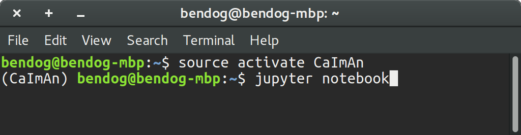

This should open up a browser window that looks like the following. This is the interface of ipython notebook. See the **[official documents](http://jupyter-notebook.readthedocs.io/en/latest/)**, **[a shorter start guide](http://nbviewer.jupyter.org/github/jupyter/notebook/blob/master/docs/source/examples/Notebook/Notebook%20Basics.ipynb)** or **[a nice cheatsheet](https://s3.amazonaws.com/assets.datacamp.com/blog_assets/Jupyter_Notebook_Cheat_Sheet.pdf)** for how to play with the ipython notebook.

[figure not shown]

Navigate to CaImAn folder on your local machine then open up demo_caiman_pipeline.ipynb

[figure not shown]

The information in Ipython Notebook are organized by "cells". There are two major types of cells: "code" which contatins codes that can be executed and corresponding outputs, and "markdown" which contains pure text and images. The best way to tell them apart is to look for "In []" and "Out []" sign at the beginning of the line, which signify the input and output of the code cell. If there is nothing at the beginning, then it's a markdown cell.

The idea of testing the enviornment is run through (use the "Cell" dropdown in the menu, if you skipped all the tutorial above) each code cell in this notebook and see if there is any error occured. The output of those lines might look messy and puzzling, but you can recognize an error easily by looking for a long dashed line, the words `Traceback (most recent call last)` and a few block of codes each with an arrow pointing to the errored line. Here is how it looks:

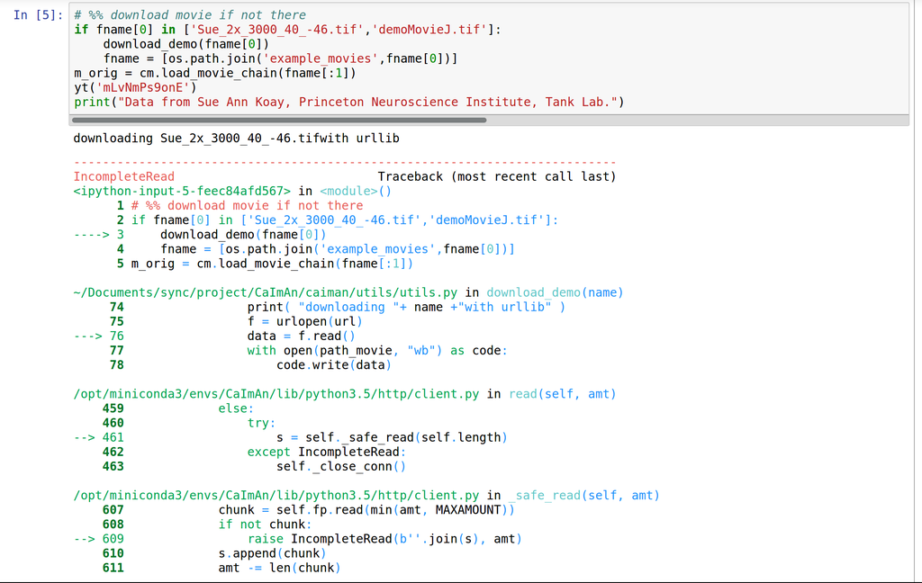

If there is no error than you are good to go! If any **ImportError** occured, then check to see if you have that package installed properly

## choosing an editor or IDE

Now, the notebook is best used for sharing and demonstration only. To actually edit and run codes productively, you need some editor or **[IDE](https://en.wikipedia.org/wiki/Integrated_development_environment)**. In theory you can edit python codes with your system text editor, and run them with a direct `python path_to_the_script.py` commands. But it's always nice to have everything integrated together like matlab, hence the need for IDE. CaImAn recommended **[spyder](https://pythonhosted.org/spyder/)**, which should already be in your enviornment. You can start spyder with `spyder` after activating your enviornment. My current personal favorite is **[PyCharm](https://www.jetbrains.com/pycharm/)**. However, I encouraged you to **[look around](https://wiki.python.org/moin/IntegratedDevelopmentEnvironments)** and find out the best fit for yourself.

## setting up IDE to use the virtual enviornment

Since we set up all the required packages in a conda virtual enviornment, we need to explicitly tell the IDE or whatever we are running to use that enviornment, instead of the system default.

Now it's perfect time to explain what I mean by "using that enviornment", and further more, how all these python terminals and virtual enviornments actually works.

Simply put, a terminal is a purly text-based interface to all kinds of applications. In **[Unix-like systems](https://en.wikipedia.org/wiki/Unix-like)**, a lot of, if not all the stuff that can be done through graphical UI (i.e. clicking), can also be done through text-based commands, with the help of **[some sort of terminals](https://en.wikipedia.org/wiki/Unix_shell)**. So how does the commands work? They are basicly little applications that get called everytime you issued a command. For example, in the CaImAn install process, this line: `git clone https://github.com/simonsfoundation/CaImAn` calls for a little program named `git`, the rest of the line is passed to the `git` to tell it what to do. You can simply type in `git` without telling it anything, for most of command-line applications this will result in printing out a help page that tells you what the application can do. You can actually find the `clone` subcommands in this help page (ignore the prepending "!", you should not add it in your terminal):

```python
!git
```

```
usage: git [--version] [--help] [-C <path>] [-c name=value]
           [--exec-path[=<path>]] [--html-path] [--man-path] [--info-path]
           [-p | --paginate | --no-pager] [--no-replace-objects] [--bare]
           [--git-dir=<path>] [--work-tree=<path>] [--namespace=<name>]
           <command> [<args>]

These are common Git commands used in various situations:

start a working area (see also: git help tutorial)
   clone      Clone a repository into a new directory
   init       Create an empty Git repository or reinitialize an existing one

work on the current change (see also: git help everyday)
   add        Add file contents to the index
   mv         Move or rename a file, a directory, or a symlink
   reset      Reset current HEAD to the specified state
   rm         Remove files from the working tree and from the index

examine the history and state (see also: git help revisions)
   bisect     Use binary search to find the commit that introduced a bug
   grep       Print lines matching a pattern
   log        Show commit logs
   show       Show various types of objects
   status     Show the working tree status

grow, mark and tweak your common history
   branch     List, create, or delete branches
   checkout   Switch branches or restore working tree files
   commit     Record changes to the repository
   diff       Show changes between commits, commit and working tree, etc
   merge      Join two or more development histories together
   rebase     Forward-port local commits to the updated upstream head
   tag        Create, list, delete or verify a tag object signed with GPG

collaborate (see also: git help workflows)
   fetch      Download objects and refs from another repository
   pull       Fetch from and integrate with another repository or a local branch
   push       Update remote refs along with associated objects

'git help -a' and 'git help -g' list available subcommands and some
concept guides. See 'git help <command>' or 'git help <concept>'
to read about a specific subcommand or concept.
```

Of course it's the same for `conda` too:

```python
!conda
```

```
usage: conda [-h] [-V] command ...

conda is a tool for managing and deploying applications, environments and packages.

Options:

positional arguments:
  command
    info         Display information about current conda install.
    help         Displays a list of available conda commands and their help
                 strings.
    list         List linked packages in a conda environment.
    search       Search for packages and display their information. The input
                 is a Python regular expression. To perform a search with a
                 search string that starts with a -, separate the search from
                 the options with --, like 'conda search -- -h'. A * in the
                 results means that package is installed in the current
                 environment. A . means that package is not installed but is
                 cached in the pkgs directory.
    create       Create a new conda environment from a list of specified
                 packages.
    install      Installs a list of packages into a specified conda
                 environment.
    update       Updates conda packages to the latest compatible version. This
                 command accepts a list of package names and updates them to
                 the latest versions that are compatible with all other
                 packages in the environment. Conda attempts to install the
                 newest versions of the requested packages. To accomplish
                 this, it may update some packages that are already installed,
                 or install additional packages. To prevent existing packages
                 from updating, use the --no-update-deps option. This may
                 force conda to install older versions of the requested
                 packages, and it does not prevent additional dependency
                 packages from being installed. If you wish to skip dependency
                 checking altogether, use the '--force' option. This may
                 result in an environment with incompatible packages, so this
                 option must be used with great caution.
    upgrade      Alias for conda update. See conda update --help.
    remove       Remove a list of packages from a specified conda environment.
    uninstall    Alias for conda remove. See conda remove --help.
    config       Modify configuration values in .condarc. This is modeled
                 after the git config command. Writes to the user .condarc
                 file (/home/bendog/.condarc) by default.
    clean        Remove unused packages and caches.
    package      Low-level conda package utility. (EXPERIMENTAL)

optional arguments:
  -h, --help     Show this help message and exit.
  -V, --version  Show the conda version number and exit.

other commands, such as "conda build", are avaialble when additional conda
packages (e.g. conda-build) are installed
```

As you can imagine, there are millions of little programs, and everytime you install something new, a (or some) new command will become available. How does the terminal magically find the application you want with only a single word? It's **[through the idea of `$PATH`](https://askubuntu.com/questions/482971/how-does-the-terminal-work)**, which is basically a collection of folders where all those little applications rests. Everytime you issue a command, the terminal search in your `$PATH` (those folders), and calls for any program whose name matches your input. Of course, it will complain if nothing is found, for example:

```python
!blah_blah_blah_something_that_dont_exsist
```

```
/bin/sh: 1: blah_blah_blah_something_that_dont_exsist: not found
```

So, unlike Windows, where installing and uninstalling programs is a state of magic, in UNIX-like systems, installing a program is simply copying the programs (or codes, essentially) to the appropriate `$PATH`, since in UNIX-like systems **[everything is a file](https://en.wikipedia.org/wiki/Everything_is_a_file)** and there's nothing special about programs.

That being said, you can imagine a circumstance where you have different version of the same program (with the same name) under different folders, and select which one you want to use by setting the search '$PATH' everytime you call for that program. This sounds like nonsense for something like office, but is extremely useful for something like python, since python has two major versions (2.x and 3.x), and all those packages depending on python will differ in some way and conflict with each other if messed up together. This is exactly what conda helped you do - create sub-folders, put python and desired additional packages in them and manage them for you, and each of those folders can be considered a self-contained virtual enviornment.

Let's see these for ourselves. By default, the directory of each virtual enviornment is simply `ROOT_DIR/envs/the_name_of_your_enviornment` where **[ROOT_DIR is the directory of your conda installation](https://conda.io/docs/user-guide/concepts.html)**. Again you can easily find these information by **[listing your enviornments](https://conda.io/docs/user-guide/tasks/manage-environments.html#viewing-a-list-of-your-environments)**

```python
!conda env list
```

```
# conda environments:
#
CaImAn                *  /opt/miniconda3/envs/CaImAn
FP                       /opt/miniconda3/envs/FP
another_python           /opt/miniconda3/envs/another_python
calblitz                 /opt/miniconda3/envs/calblitz
spyder                   /opt/miniconda3/envs/spyder
root                     /opt/miniconda3
```

You can see my current activated enviornment is `CaImAn`(signified by a star). Here is what is looks like in the enviornment directory:

```python
!tree -d -L 2 /opt/miniconda3/envs/CaImAn
```

```
/opt/miniconda3/envs/CaImAn
├── bin
├── conda-meta
├── doc
│   └── global
├── etc
│   ├── dbus-1
│   ├── fonts
│   ├── jupyter
│   └── rc.d
├── include
│   ├── cairo
│   ├── curl
│   ├── dbus-1.0
│   ├── fontconfig
│   ├── freetype2
│   ├── gio-unix-2.0
│   ├── glib-2.0
│   ├── gstreamer-1.0
│   ├── harfbuzz
│   ├── layout
│   ├── libpng16
│   ├── libxml2
│   ├── lzma
│   ├── opencv
│   ├── opencv2
│   ├── openssl
│   ├── pixman-1
│   ├── python3.5m
│   ├── qt
│   ├── readline
│   ├── sodium
│   ├── unicode
│   └── xcb
├── lib
│   ├── cairo
│   ├── cmake
│   ├── dbus-1.0
│   ├── engines
│   ├── glib-2.0
```

[output cut: 145 more lines]

```
│   ├── jupyter
│   ├── locale
│   ├── man
│   ├── metainfo
│   ├── OpenCV
│   ├── pixmaps
│   ├── sip
│   └── xml
├── ssl
│   └── misc
├── translations
└── var
    └── cache

197 directories
```

The python executable file specific to this enviornment is actually in the `bin` folder. We can directly invoke python there:

```python
!/opt/miniconda3/envs/CaImAn/bin/python -c 'print("hey there!")'
```

```
hey there!
```

That said, each time you do `source activate some_enviornment`, what's actually happening is that conda point the `$PATH` variable to the desired enviornment directory for you, so that afterwards when you call `python`, it's actually running the python executable file inside that enviornment folder, instead of the system default one.

Now, it turns out that python use exactly the same idea to search for all those additional packages - a `$PATH` variable. The difference is that python has its own **[`$PYTHONPATH`](https://docs.python.org/2/using/cmdline.html#envvar-PYTHONPATH)** variable which is distinct from the global system-default `$PATH` variable. Whenever you ask for a module (i.e. packages) in python, it search in the directories listed under `$PYTHONPATH`. Conveniently, when you invoke `python` from different places, the `$PYTHONPATH` variable is **[automatically set relative to the python executable](https://leemendelowitz.github.io/blog/how-does-python-find-packages.html)**, so neither you nor conda need to worry about setting that properly. To demonstrate, let's invoke python from different places and ask it to tell us which `$PYTHONPATH` it's using (the string after `-c` is a tiny piece of python code printing out the `$PYTHONPATH` variable, you don't have to worry about that):

```python
!/opt/miniconda3/envs/CaImAn/bin/python -c 'import sys; print("\n".join(sys.path))'
```

```
/opt/miniconda3/envs/CaImAn/lib/python35.zip
/opt/miniconda3/envs/CaImAn/lib/python3.5
/opt/miniconda3/envs/CaImAn/lib/python3.5/plat-linux
/opt/miniconda3/envs/CaImAn/lib/python3.5/lib-dynload
/opt/miniconda3/envs/CaImAn/lib/python3.5/site-packages
/opt/miniconda3/envs/CaImAn/lib/python3.5/site-packages/Sphinx-1.6.3-py3.5.egg
```

As you can see, the python in `CaImAn` enviornment is searching for directories under `/opt/miniconda3/envs/CaImAn/lib`, which will change if we call for another python from difference place:

```python
!/opt/miniconda3/envs/calblitz/bin/python -c 'import sys; print("\n".join(sys.path))'
```

```
/opt/miniconda3/envs/calblitz/lib/python27.zip
/opt/miniconda3/envs/calblitz/lib/python2.7
/opt/miniconda3/envs/calblitz/lib/python2.7/plat-linux2
/opt/miniconda3/envs/calblitz/lib/python2.7/lib-tk
/opt/miniconda3/envs/calblitz/lib/python2.7/lib-old
/opt/miniconda3/envs/calblitz/lib/python2.7/lib-dynload
/opt/miniconda3/envs/calblitz/lib/python2.7/site-packages
/opt/miniconda3/envs/calblitz/lib/python2.7/site-packages/setuptools-27.2.0-py2.7.egg
```

This is a long explanation about how the conda enviornments work and hopefully it make sense. Now we can set out and ask our IDE to use the enviornments. In most cases, it's very simple - make sure you `source activate your_enviornment`, and then simply invoke `python`, `ipython` or `spyder` from there (hopefully you already figured this out yourself after the long explanation). For more complicated IDEs who like to control everything inside their program (like PyCharm), this does not work. But the basic idea stays the same - you need to point the IDE to the proper python executable you want to use and then you're set. **[Here](https://www.jetbrains.com/help/pycharm/configuring-python-interpreter.html)** is the official guide of how to do that in PyCharm (follow the "Configuring a local interpreter" part - we don't need to use the `virtualenv` tool from PyCharm since we already have conda doing that for us). If you are using neither spyder or PyCharm, the best way to find out how to do this is **[google "[your IDE name] + set python interpreter"](https://www.google.com/search?client=ubuntu&hs=0FY&channel=fs&q=pycharm+set+python+interpreter&spell=1&sa=X&ved=0ahUKEwjXuoaJvvrWAhUGJiYKHZ6FANEQvwUIIygA&biw=1440&bih=793)**.